## Overview

- Aim is to estimate case fatality for several chronic diseases and city regions of England to inform the METAHIT transport and health impact model.
- 9 city regions (Bristol, Liverpool, London, West Midlands, Sheffield, North East, Greater Manchester, Nottingham, Leeds)
- Diseases: six cancers (colorectal, liver, stomach, lung/trachea/bronchus, female breast, uterus), cardiovascular disease (general), ischaemic heart disease, ischaemic stroke, other stroke, dementia, COPD *[though these may change?]*
- Data from the Global Burden of Disease study on incidence, prevalence and mortality are used.
- Bayesian methods are used to estimate case fatality based on these data and some model assumptions. The principles behind the methods are explained in the main disbayes vignette. Further details are given in this document on specific model assumptions that are used in this application.

## Model assumptions

- We assume the data arise from a three-state continuous-time Markov model with states representing no disease, disease and death from the disease, and parameters representing the transition rate from no disease to disease (incidence) and from disease to death from the disease (case fatality).
- Incidence and case fatality are assumed to depend on age, gender and area. There is not enough data to estimate case fatality independently for each combination of age, gender and area. However we can produce usefully-precise estimates under plausible assumptions about how the categories are related to each other.
- For all diseases, we assume that case fatality is a smooth spline function of age, with constant case fatality for age 50 and below. Further assumptions are used where necessary to obtain usefully-precise area-specific estimates for particular diseases.
- Two alternative assumptions are used for the *dependence on areas* (implemented for all diseases)
  1. Independent, area-specific estimates, based on the model explained in the main disbayes vignette.
  2. Hierarchical model. Allows data from other areas to inform the estimates from a weakly-informed area. Explained in the hierarchical model vignette.
- Two alternative assumptions are assumed for the *dependence on ages*
  1. No further restrictions on the smooth spline function
  2. *Non-decreasing* case fatality with age (used for trachea/bronchus/lung cancer)
  3. An “unsmoothed” model has also been implemented, where case fatalities for each year of age are estimated independently of the data from adjacent ages. While this model is not used to generate results for METAHIT, it is still useful to identify where there is insufficient information about case fatality at particular ages (generally due to low prevalence at younger ages), thus extra assumptions about model structure are required, e.g. borrowing information between ages. Results of these models are not presented in this document,. An illustration is given in the main disbayes vignette.
- *Dependence on gender*. A further set of models is fitted where the effect of gender is the same for each area. In other words, there is no interaction between gender and area. While this restriction is not necessary to produce *reasonable* estimates, the intention is to produce more *precise* estimates by borrowing information between the data for men and women.
- Software implementation. All models are implemented in Stan, as described in the main disbayes vignette. Though the disbayes package currently only includes the independent area-specific model (1) - the hierarchical models could be included, but I wouldn’t recommend them for non-expert use until they have been tested in other examples.

## Summary of results

### Figure 1: between area variability in point and interval estimates, IHD, age 60

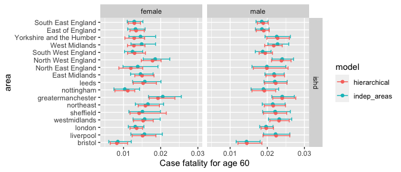

### Figure 2: between area variability in age curves (IHD, point estimates)

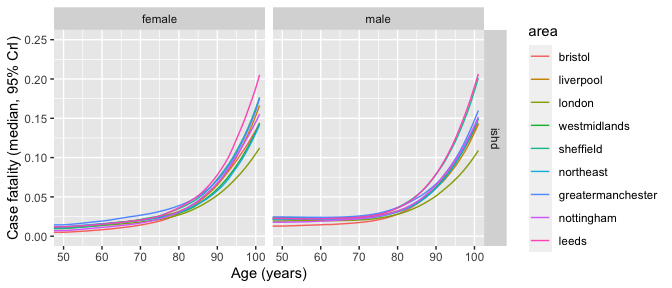

### Figure 3: trachea, bronchus and lung cancer, male, point estimates from the model compared with related national estimates

Solid blue: estimates of net survival (converted from 5-year survival probabilities to rates) from lung cancer in England, by broad age groups, for adults diagnosed between 2013 and 2017 and followed up to 2018 (ONS).

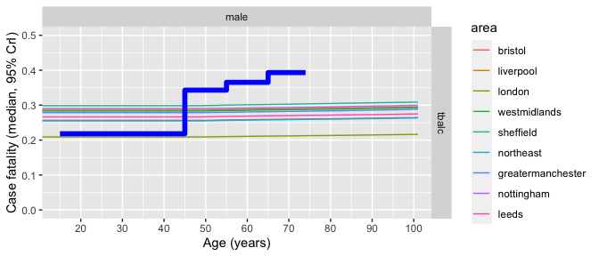

### Figure 4: assumptions about the gender effect compared

Case fatality for COPD in Bristol.

`hier_gender` indicates the model that assumes the gender effect is the same in each area. `hierarchical` indicates the model with a different gender effect per area.

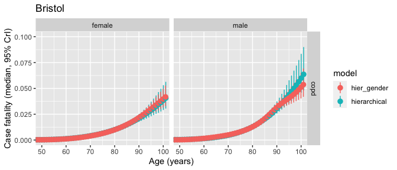

## Full results plots

Estimates presented as two figures for each city: first figure including diseases other than cancer

- adaod: Alzheimer’s disease and other dementia
- copd: chronic obstructive pulmonary disease
- crdd: cardiovascular diseases (general)
- iscs: ischaemic stroke
- ishd: ischaemic heart disease
- strk: stroke

*[ may also be type II diabetes here currently, but I think this will be treated differently ]*

and second figure including cancers

- brsc: breast cancer
- carc: colon and rectum cancer
- lvrc: liver cancer
- stmc: stomach cancer
- tbalc: trachea, bronchus and lung cancer
- utrc: uterine cancer

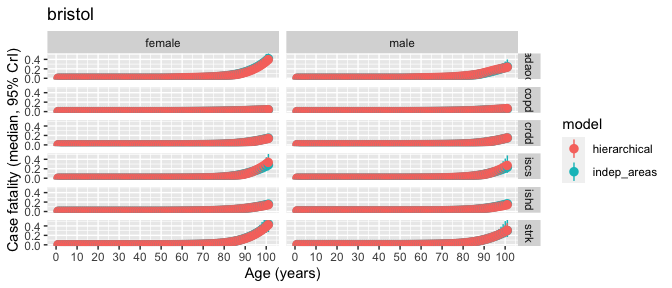

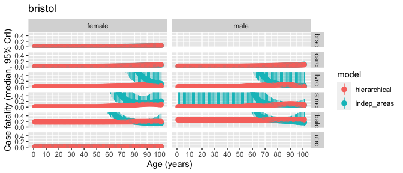

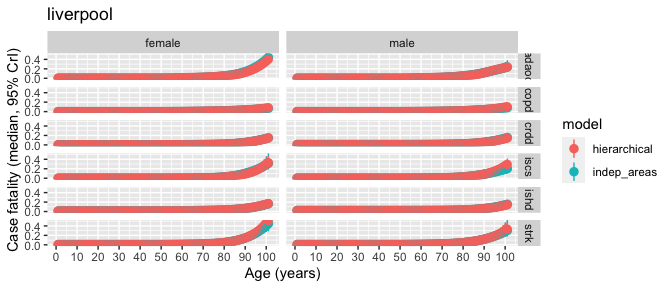

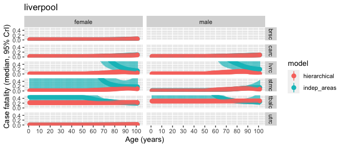

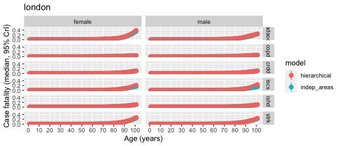

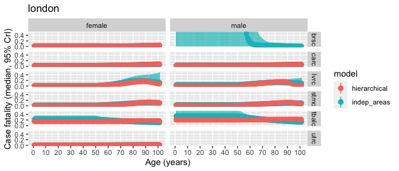

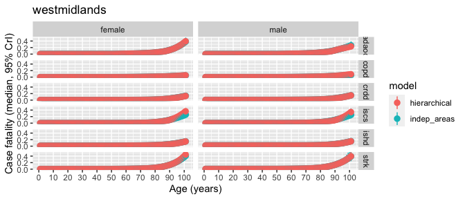

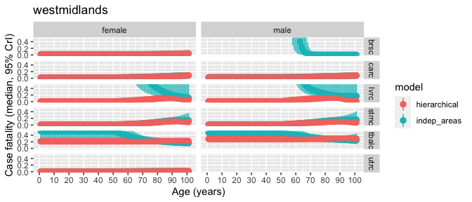

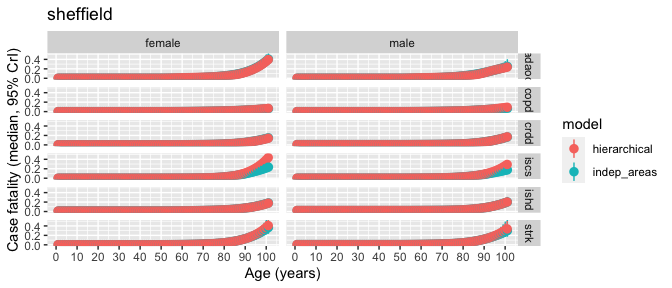

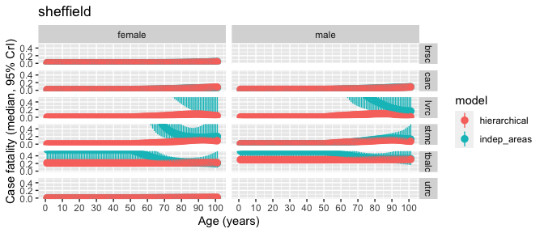

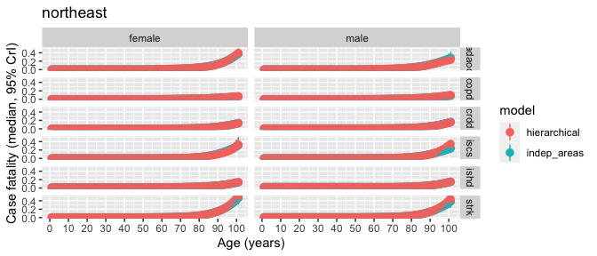

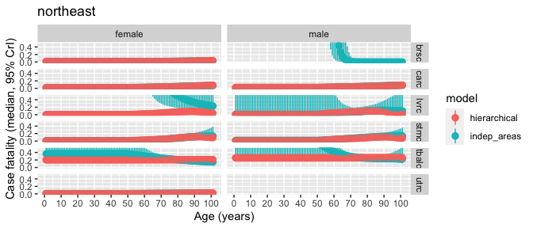

[6 more figures not shown]

## TODO

- Statistical model comparison (cross-validation / DIC-like method) for some of these
- Finish with final METAHIT diseases / settings.
- Discuss any other sources of uncertainty that are relevant to health impacts - e.g. trends through calendar time?

## Selling points for an applied statistics journal

- A widely-used class of health impact simulation models requires disease incidence and case fatality to be represented as an explicit stochastic processes that we can simulate from (either at an aggregate or individual level) .
  - contrast this class of models with e.g. “comparative risk assessment” models, that are even more widely used to assess health impacts, but make stronger assumptions about age dependence
- Avalilability of data to inform different parts of that process varies with context, but typically the case fatality is the least well informed. GBD is the most convenient source for models that can be adapted easily to different global contexts, but GBD don’t publish estimates of case fatality.
- Barendregt et al method implemented in the DisMod II software is typically used in practice for this. We can easily explain advantages of a Bayesian alternative (see main disbayes vignette).
- Flaxman et al book describes the principles of Bayesian estimation of disease epidemiology from incomplete data. We are applying those principles to a specific situation, and using a specific model, that was not described in that book, and that the associated software doesn’t handle.
- For an applied statistics journal, highlight interesting data features and modelling challenges that aren’t explicitly discussed by Flaxman et al., e.g.
  - borrowing info between ages, genders and areas, and statistical comparison of different assumptions
  - more flexible and parsimonious spline models for age with smoothness controlled by penalisation
  - nice way of constraining splines to be increasing where needed
  - hierarchical splines anchored on linear trends
- We develop an R package to implement our methods.
- Remember the work is motivated by estimating health impacts of interventions/scenarios. While the example is based on METAHIT transport model, this paper isn’t about a specific health impact, rather to show a generic method that is applicable to different settings. Emphasise that the method enables transparent uncertainty propagation for health impact estimates.